# Section 1: Make a New File

```python
import numpy as np
import pandas as pd
import matplotlib.pyplot as plt
%matplotlib inline
```

# Section 2: Exoplanet Data

## Q1: Examining Data Files

```python
!head -n 20 exoplanets.csv
```

```
#
# This text file contains four columns:
#  [1] the name of an exoplanet
#  [2] planet's radius, in Earth radii
#  [3] star's radius, in solar radii
#  [4] energy flux the planet receives from its star,
#       (relative to what Earth receives from the Sun)
#
55 Cnce,            2.17,  0.94, 2.44e+03
BD+20 594b,         2.23,  0.93, 1.48e+01
CoRoT-10b,         10.87,  0.79, 2.82e+01
CoRoT-11b,         16.03,  1.37, 1.51e+03
CoRoT-12b,         16.14,  1.12, 7.27e+02
CoRoT-13b,          9.92,  1.01, 4.45e+02
CoRoT-14b,         12.22,  1.21, 2.42e+03
CoRoT-16b,         13.11,  1.19, 3.39e+02
CoRoT-17b,         11.43,  1.59, 1.17e+03
CoRoT-18b,         14.68,  1.00, 9.05e+02
CoRoT-19b,         14.46,  1.65, 1.28e+03
CoRoT-1b,          16.70,  1.11, 2.16e+03
```

```python
!tail -n 10 exoplanets.csv
```

```
WASP-97b,          12.67,  1.06, 9.38e+02
WASP-98b,          12.82,  0.74, 3.14e+02
WASP-99b,          12.33,  1.76, 7.94e+02
WTS-1b,            16.70,  1.15, 8.38e+02
WTS-2b,            15.28,  0.75, 9.21e+02
XO-1b,             13.56,  0.94, 3.58e+02
XO-2 Nb,           11.42,  1.01, 5.49e+02
XO-3b,             13.64,  1.38, 1.43e+03
XO-4b,             14.91,  1.55, 7.46e+02
XO-5b,             12.78,  1.13, 3.77e+02
```

**Q1: This is a comma-delimited text file with comment lines marked by # signs. It has four columns of data, which are, from left to right, the name of an exoplanet, its radius in units of Earth radii, its star's radius in units of solar radii, and its insolation in terms of Earth's energy flux from the Sun.**

```python
!head -n 20 newplanet.lightcurve
```

```
#  time    flux
# (days) (relative)
-0.09422 0.997265
-0.09353 1.000602
-0.09284 0.997030
-0.09214 1.000346
-0.09145 1.002287
-0.09075 1.000413
-0.09006 1.003608
-0.08936 0.998366
-0.08867 0.997157
-0.08797 1.001759
-0.08728 1.000729
-0.08659 1.001615
-0.08589 0.999062
-0.08520 0.999785
-0.08450 0.997915
-0.08381 0.998039
-0.08311 1.000046
-0.08242 0.997452
```

```python
!tail newplanet.lightcurve
```

```
0.08980 1.002031
0.09050 1.001891
0.09119 0.998491
0.09189 1.000615
0.09258 0.996631
0.09328 1.000481
0.09397 0.999387
0.09466 0.998009
0.09536 1.000461
0.09605 0.998436
```

**Q1b. This is a text file with two columns delimited by whitespace, comment lines marked by #signs. The text file is quite poorly documented within the file itself, but we can determine from other sources that the columns are time, measured in units of days away from the middle of a planet's transit of its star, and energy flux, expressed as a fraction of the normal brightness of the star when a planet is not transiting.**

## Q2: Reading Exoplanet Data

```python
exoplanets_panda = pd.read_csv('exoplanets.csv',sep=',\s+',comment='#',
        names=['name','planet_radius','star_radius','insolation'],engine='python')  #read in data to a pandas table
```

```python
exoplanets_panda                #check data
```

|  | name | planet_radius | star_radius | insolation |
| --- | --- | --- | --- | --- |
| 0 | 55 Cnce | 2.17 | 0.94 | 2440.0 |
| 1 | BD+20 594b | 2.23 | 0.93 | 14.8 |
| 2 | CoRoT-10b | 10.87 | 0.79 | 28.2 |
| 3 | CoRoT-11b | 16.03 | 1.37 | 1510.0 |
| 4 | CoRoT-12b | 16.14 | 1.12 | 727.0 |
| ... | ... | ... | ... | ... |
| 2403 | XO-1b | 13.56 | 0.94 | 358.0 |
| 2404 | XO-2 Nb | 11.42 | 1.01 | 549.0 |
| 2405 | XO-3b | 13.64 | 1.38 | 1430.0 |
| 2406 | XO-4b | 14.91 | 1.55 | 746.0 |
| 2407 | XO-5b | 12.78 | 1.13 | 377.0 |

2408 rows × 4 columns

```python
exoplanet_names = exoplanets_panda['name']                   #transfer columns to numpy arrays for easier handling
exoplanet_radius = exoplanets_panda['planet_radius']
exoplanet_stellar_radius = exoplanets_panda['star_radius']
exoplanet_flux = exoplanets_panda['insolation']
```

```python
print (exoplanet_names)                                      #check arrays
```

```
0          55 Cnce
1       BD+20 594b
2        CoRoT-10b
3        CoRoT-11b
4        CoRoT-12b
           ...
2403         XO-1b
2404       XO-2 Nb
2405         XO-3b
2406         XO-4b
2407         XO-5b
Name: name, Length: 2408, dtype: object
```

```python
print(exoplanet_flux)
```

```
0       2440.0
1         14.8
2         28.2
3       1510.0
4        727.0
         ...
2403     358.0
2404     549.0
2405    1430.0
2406     746.0
2407     377.0
Name: insolation, Length: 2408, dtype: float64
```

## Q3: Plotting Exoplanet Data

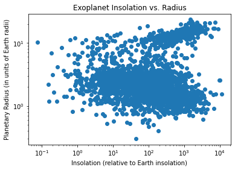

```python
plt.scatter(exoplanet_flux,exoplanet_radius)                  #use scatter plot for this type of data
plt.xscale('log')                                             #set axes to log scale
plt.yscale('log')
plt.title ("Exoplanet Insolation vs. Radius")                 #label axes
plt.xlabel ('Insolation (relative to Earth insolation)')
plt.ylabel ('Planetary Radius (in units of Earth radii)');
```

## Q4: More Plotting of Exoplanet Data

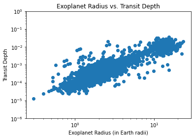

```python
earthRadius = 6.371e6             #Earth's radius in m
sunRadius = 6.957e8               #the Sun's radius in m
transit_depth = ((exoplanet_radius*earthRadius)/(exoplanet_stellar_radius*sunRadius))**2  #calculate transit depth
plt.scatter(exoplanet_radius,transit_depth)
plt.xscale('log')                                  #set axes to log scale
plt.yscale('log')
plt.ylim(1e-6,1)                                   #set y-axis as instructed
plt.title ("Exoplanet Radius vs. Transit Depth")   #label axes
plt.xlabel ('Exoplanet Radius (in Earth radii)')
plt.ylabel ('Transit Depth');
```

## Q5: Make a Dictionary

```python
exoplanets = {}                                       #create blank dictionary
for i,j in zip(exoplanet_names, exoplanet_radius):  #loop through names and radii using zip
    exoplanets[i] = j                                #exoplanets['name'] = radius
```

```python
print(len(exoplanet_names))
print(len(exoplanet_radius))
print(len(exoplanets))                              #check that dictionary got all planets
print(exoplanets['Kepler-42b'])                     #check dictionary value
print(exoplanets['Kepler-42c'])
print(exoplanets['Kepler-42d'])
```

```
2408
2408
2408
0.78
0.73
0.57
```

## Q6: Read In New Planet Data

```python
newplanet_lightcurve = pd.read_csv('newplanet.lightcurve',sep='\s+',comment='#',
                         names=['time','flux'])                                    #read in newplanet.lightcurve
newplanet_lightcurve                                                               #check data
```

|  | time | flux |
| --- | --- | --- |
| 0 | -0.09422 | 0.997265 |
| 1 | -0.09353 | 1.000602 |
| 2 | -0.09284 | 0.997030 |
| 3 | -0.09214 | 1.000346 |
| 4 | -0.09145 | 1.002287 |
| ... | ... | ... |
| 270 | 0.09328 | 1.000481 |
| 271 | 0.09397 | 0.999387 |
| 272 | 0.09466 | 0.998009 |
| 273 | 0.09536 | 1.000461 |
| 274 | 0.09605 | 0.998436 |

275 rows × 2 columns

```python
newplanet_time = newplanet_lightcurve['time']            #convert to numpy arrays
newplanet_flux = newplanet_lightcurve['flux']
```

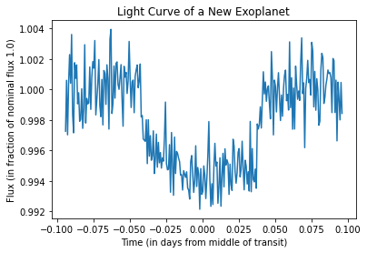

```python
plt.plot(newplanet_time,newplanet_flux)                  #line plot is appropriate for this data
plt.title ('Light Curve of a New Exoplanet')
plt.ylabel ('Flux (in fraction of nominal flux 1.0)')
plt.xlabel ('Time (in days from middle of transit)');
```

## Q7: Estimate Transit Depth From Plot

```python
D = 0.006                                                   #estimated transit depth from flux value of 0.994 on above plot
newplanet_radius = (np.sqrt(((0.2*sunRadius)**2)*D))/earthRadius     #calulate new planet's radius in Earth radii
print(newplanet_radius)
```

```
1.6916870280687488
```

```python
exoplanets['Shanesworld']=newplanet_radius          #add to dictionary
```

## Q8: Plot New Planet

```python
newplanet_insolation = (0.004/1)*((1/0.11)**2)      #calculate insolation (relative to Earth)
print(newplanet_insolation)                         #check value
```

```
0.3305785123966943
```

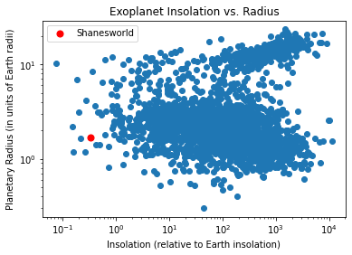

```python
plt.scatter(exoplanet_flux,exoplanet_radius)                  #reuse scatter plot of insolation vs radius
plt.scatter(newplanet_insolation,newplanet_radius,label='Shanesworld',c='r',s=50)    #plot new planet
plt.legend()                                                                         #label new planet
plt.xscale('log')
plt.yscale('log')
plt.title ("Exoplanet Insolation vs. Radius")
plt.xlabel ('Insolation (relative to Earth insolation)')
plt.ylabel ('Planetary Radius (in units of Earth radii)');             #new planet is reasonably positioned
```

## Q9: Discuss Exoplanets

Q9: The fact that we are discovering planets around other stars is quite amazing, but I think it is very important for both the public and the scientific community not to grow complacent. I believe it is necessary to move beyond the transit method as soon as possible.

The transit method of detecting planets has serious limitations, in that it introduces multiple significant biases into our planetary dataset. Transit detection biases planet detection towards planets that are close to their stars, and whose orbital planes are edge-on to our own position. Having confirmed that extrasolar planets are common, the next step is to do as comprehensive a survey as possible, in order to refine our models of planetary formation and evolution, and to characterize the galactic planetary population.

How common are rocky planets vs. gas giants? How common are Jupiter and Saturn-like gas giants vs. ice giants like Uranus and Neptune? How common are rocky planets with gaseous atmospheres? How common are potentially habitable planets?

None of these questions can be answered with rigor until we can do a more comprehensive survey of nearby planets, without the biases that transit detection introduces. I've read promising things about using carefully structured sunshades to directly image planets around nearby stars, and if I had any control over space-based scientific funding, that's what I would be doing.